# Презентация по лабораторной работе №6

Модель эпидемии

Озьяс Стев Икнэль Дани

# Информация

## Докладчик

- Озьяс Стев Икнэль Дани
- студент группы НКНбд-01-21
- Российский университет дружбы народов
- https://github.com/Dacossti

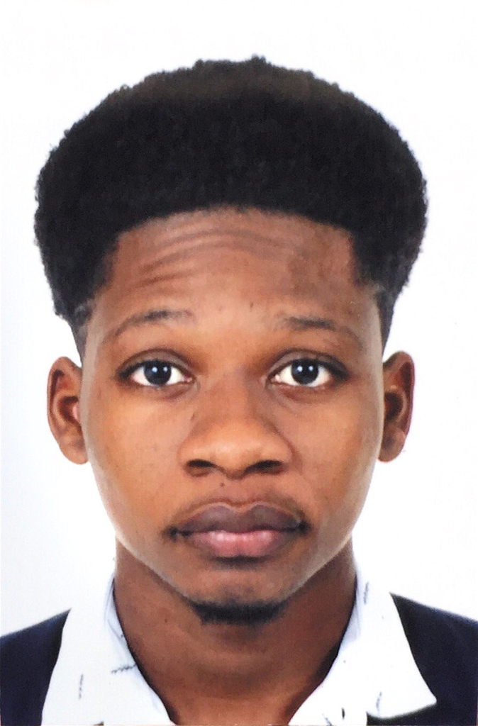

# Цели и задачи работы

## Цель лабораторной работы

Рассмотрим простейшую модель эпидемии. Предположим, что некая популяция, состоящая из N особей, (считаем, что популяция изолирована) подразделяется на три группы. Первая группа - это восприимчивые к болезни, но пока здоровые особи, обозначим их через $S(t)$. Вторая группа – это число инфицированных особей, которые также при этом являются распространителями инфекции, обозначим их $I(t)$. А третья группа, обозначающаяся через $R(t)$ – это здоровые особи с иммунитетом к болезни.

## Задание к лабораторной работе

Постройте графики изменения числа особей в каждой из трех групп.

Рассмотрите, как будет протекать эпидемия в случае:

1. если $I(0) \leq I^{*}$
2. если $I(0) > I^{*}$

# Процесс выполнения лабораторной работы

## Решение

На одном острове вспыхнула эпидемия. Известно, что из всех проживающих на острове $N=11 300$ в момент начала эпидемии $t=0$ число заболевших людей (являющихся распространителями инфекции) $I(0)=240$, А число здоровых людей с иммунитетом к болезни $R(0)=46$. Таким образом, число людей восприимчивых к болезни, но пока здоровых, в начальный момент времени $S(0)=N-I(0)- R(0)$.

## Решение

Постройте графики изменения числа особей в каждой из трех групп.

Рассмотрите, как будет протекать эпидемия в случае:

1. если $I(0) \leq I^{*}$

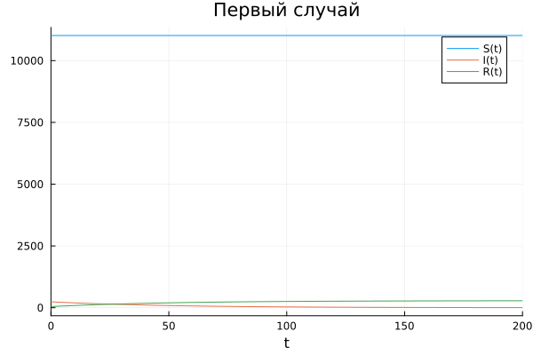

Динамика изменения числа особей - Случай 1 (Julia)

## Решение

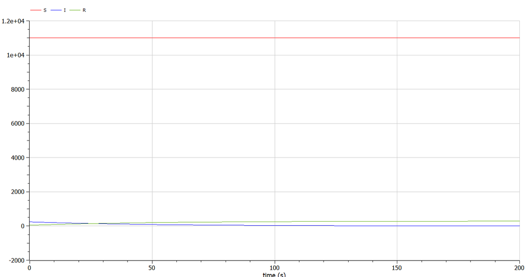

Динамика изменения числа особей - Случай 1 (OpenModelica)

## Решение

2. если $I(0) > I^{*}$

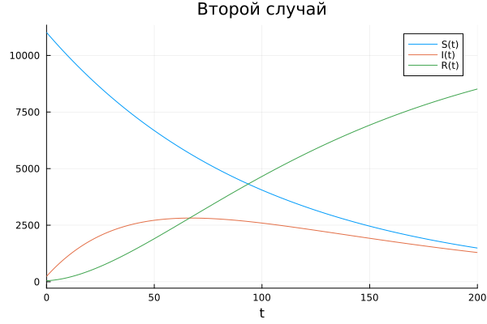

Динамика изменения числа особей - Случай 2 (Julia)

## Решение

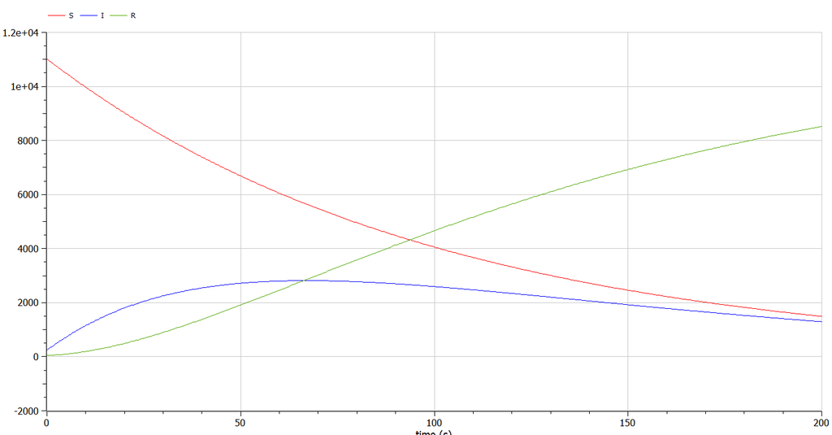

Динамика изменения числа особей - Случай 2 (OpenModelica)

# Выводы по проделанной работе

## Вывод

В результате проделанной лабораторной работы мы познакомились с моделем эпидемии.

Проверили, как работает модель в различных ситуациях, показали динамику изменения числа людей в каждой из трех групп в каждом случае.

# Список литературы

1. [Модель эпидемии](https://hal.science/hal-02509142v4/file/epidemie_ru.pdf)